# Analysis of Animal Rescues (tidytuesday)

Tóth Mercédesz

# 🐾 About the dataset 🐾

The dataset includes data about the London Fire Brigade’s **animal rescues** since **January 2009**. As provided in the official dataset description, in **2020**, there was a **20% increase** in rescues compared to 2019. The biggest increase was observed among **non-domestic animals**.

The **codebook** is available [here.](https://github.com/rfordatascience/tidytuesday/blob/main/data/2021/2021-06-29/readme.md)

# 🐾 Goals of this analysis 🐾

In this analysis, I will:  
- prepare the dataset, compute variables and visualize them;  
- confirm the rise in rescues by plotting (also comparing domestic and wild animals);  
- look for relationships between variables of interest;  
- investigate whether non-domestic animals’ rescue costs more money than domestic animals’ rescue by fitting a linear regression model;  
- investigate what other factors influence rescue cost with a more complex linear regression model;  
- compare the simple and the more complex models’ performance.

In both models, the **outcome** variable will be incident_notional_cost.  
My hypothesis is that **rescuing non-domestic animals is more expensive**.

In the more complex model, I will include the following **predictors**:  
- day_or_night: computed from date_time_of_call (0: day, 1: night);  
- pump_count: number of trucks needed for the rescue;  
- pump_hours_total: length of rescue operation;  
- domestic_wild: computed from animal_group_parent (0: domestic; 1: wild);  
- borough_inner_outer: computed from borough based on [Wikipedia](https://en.wikipedia.org/wiki/London_boroughs) (0: inner; 1: outer).

**See the whole repository made for this project [here.](https://github.com/tothmercedesz2002/R-course-final)**

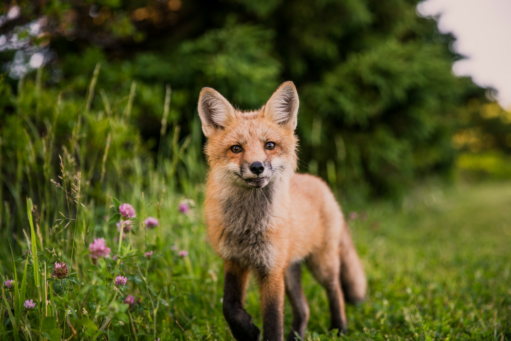

*Photo by Scott Walsh on Unsplash*

# 🐾 Setup 🐾

## Loading packages

```r
library(tidyverse)
library(skimr)
library(correlation)
library(performance)
library(broom)
library(car)
library(lmtest)
library(ggcorrplot)
library(lm.beta)
library(ggfortify)
library(lubridate)
```

## Reading the dataset

```r
animal_rescues_raw <- read_csv("https://raw.githubusercontent.com/rfordatascience/tidytuesday/main/data/2021/2021-06-29/animal_rescues.csv")
```

# 🐾 Preparation and EDA 🐾

In this section, I am going to look at the dataset, select the variables that I would like to work with, look for missing values, and convert variables. Then, I am going to compute some variables. I will do exploratory data analysis as well via plotting.

## First look at the dataset, filtering data and converting variables

### Checking dataset’s structure and variables’ type

```r
str(animal_rescues_raw)
```

```
## spc_tbl_ [7,544 × 31] (S3: spec_tbl_df/tbl_df/tbl/data.frame)
##  $ incident_number              : num [1:7544] 139091 275091 2075091 2872091 3553091 ...
##  $ date_time_of_call            : chr [1:7544] "01/01/2009 03:01" "01/01/2009 08:51" "04/01/2009 10:07" "05/01/2009 12:27" ...
##  $ cal_year                     : num [1:7544] 2009 2009 2009 2009 2009 ...
##  $ fin_year                     : chr [1:7544] "2008/09" "2008/09" "2008/09" "2008/09" ...
##  $ type_of_incident             : chr [1:7544] "Special Service" "Special Service" "Special Service" "Special Service" ...
##  $ pump_count                   : chr [1:7544] "1" "1" "1" "1" ...
##  $ pump_hours_total             : chr [1:7544] "2" "1" "1" "1" ...
##  $ hourly_notional_cost         : num [1:7544] 255 255 255 255 255 255 255 255 255 255 ...
##  $ incident_notional_cost       : chr [1:7544] "510" "255" "255" "255" ...
##  $ final_description            : chr [1:7544] "Redacted" "Redacted" "Redacted" "Redacted" ...
##  $ animal_group_parent          : chr [1:7544] "Dog" "Fox" "Dog" "Horse" ...
##  $ originof_call                : chr [1:7544] "Person (land line)" "Person (land line)" "Person (mobile)" "Person (mobile)" ...
##  $ property_type                : chr [1:7544] "House - single occupancy" "Railings" "Pipe or drain" "Intensive Farming Sheds (chickens, pigs etc)" ...
##  $ property_category            : chr [1:7544] "Dwelling" "Outdoor Structure" "Outdoor Structure" "Non Residential" ...
##  $ special_service_type_category: chr [1:7544] "Other animal assistance" "Other animal assistance" "Animal rescue from below ground" "Animal rescue from water" ...
##  $ special_service_type         : chr [1:7544] "Animal assistance involving livestock - Other action" "Animal assistance involving livestock - Other action" "Animal rescue from below ground - Domestic pet" "Animal rescue from water - Farm animal" ...
##  $ ward_code                    : chr [1:7544] "E05011467" "E05000169" "E05000558" "E05000330" ...
##  $ ward                         : chr [1:7544] "Crystal Palace & Upper Norwood" "Woodside" "Carshalton Central" "Harefield" ...
##  $ borough_code                 : chr [1:7544] "E09000008" "E09000008" "E09000029" "E09000017" ...
##  $ borough                      : chr [1:7544] "Croydon" "Croydon" "Sutton" "Hillingdon" ...
##  $ stn_ground_name              : chr [1:7544] "Norbury" "Woodside" "Wallington" "Ruislip" ...
##  $ uprn                         : chr [1:7544] "NULL" "NULL" "NULL" "1.00021E+11" ...
##  $ street                       : chr [1:7544] "Waddington Way" "Grasmere Road" "Mill Lane" "Park Lane" ...
##  $ usrn                         : chr [1:7544] "20500146" "NULL" "NULL" "21401484" ...
##  $ postcode_district            : chr [1:7544] "SE19" "SE25" "SM5" "UB9" ...
##  $ easting_m                    : chr [1:7544] "NULL" "534785" "528041" "504689" ...
##  $ northing_m                   : chr [1:7544] "NULL" "167546" "164923" "190685" ...
##  $ easting_rounded              : num [1:7544] 532350 534750 528050 504650 554650 ...
##  $ northing_rounded             : num [1:7544] 170050 167550 164950 190650 192350 ...
##  $ latitude                     : chr [1:7544] "NULL" "51.39095371" "51.36894086" "51.60528344" ...
##  $ longitude                    : chr [1:7544] "NULL" "-0.064166887" "-0.161985191" "-0.489683853" ...
##  - attr(*, "spec")=
##   .. cols(
##   ..   incident_number = col_double(),
##   ..   date_time_of_call = col_character(),
##   ..   cal_year = col_double(),
##   ..   fin_year = col_character(),
##   ..   type_of_incident = col_character(),
##   ..   pump_count = col_character(),
```

[output cut: 12 more lines]

```
##   ..   borough_code = col_character(),
##   ..   borough = col_character(),
##   ..   stn_ground_name = col_character(),
##   ..   uprn = col_character(),
##   ..   street = col_character(),
##   ..   usrn = col_character(),
##   ..   postcode_district = col_character(),
##   ..   easting_m = col_character(),
##   ..   northing_m = col_character(),
##   ..   easting_rounded = col_double(),
##   ..   northing_rounded = col_double(),
##   ..   latitude = col_character(),
##   ..   longitude = col_character()
##   .. )
##  - attr(*, "problems")=<externalptr>
```

### Selecting variables of interest

```r
animal_rescues_interest <- animal_rescues_raw %>%
  select(date_time_of_call, cal_year, pump_count, pump_hours_total, incident_notional_cost, animal_group_parent, borough)
```

### Looking for missing data

```r
sum(is.na(animal_rescues_interest))
```

```
## [1] 9
```

```r
which(rowSums(is.na(animal_rescues_interest)) > 0)
```

```
## [1] 4138 4165 4246 4709 5897 6339 6768 7072 7478
```

```r
missing_info <- animal_rescues_interest[c(4138, 4165, 4246, 4709, 5897, 6339, 6768, 7072, 7478), ]
print(missing_info)
```

```
## # A tibble: 9 × 7
##   date_time_of_call cal_year pump_count pump_hours_total incident_notional_cost
##   <chr>                <dbl> <chr>      <chr>            <chr>
## 1 25/01/2016 18:03      2016 1          2                596
## 2 24/02/2016 21:03      2016 1          1                298
## 3 28/04/2016 15:00      2016 1          2                652
## 4 26/12/2016 13:30      2016 1          1                326
## 5 30/01/2019 11:26      2019 2          3                999
## 6 23/09/2019 18:44      2019 1          2                678
## 7 10/06/2020 13:56      2020 1          1                346
## 8 02/10/2020 12:38      2020 1          1                346
## 9 09/05/2021 09:46      2021 1          3                1056
## # ℹ 2 more variables: animal_group_parent <chr>, borough <chr>
```

```r
unique(animal_rescues_interest$pump_count)
```

```
## [1] "1"    "2"    "3"    "NULL" "4"
```

```r
unique(animal_rescues_interest$pump_hours_total)
```

```
##  [1] "2"    "1"    "3"    "5"    "7"    "4"    "NULL" "6"    "8"    "9"
## [11] "12"   "10"   "0"
```

```r
unique(animal_rescues_interest$incident_notional_cost)
```

```
##  [1] "510"  "255"  "765"  "1275" "260"  "520"  "780"  "1820" "1040" "NULL"
## [11] "1300" "1560" "2080" "2340" "290"  "580"  "870"  "3480" "1160" "2030"
## [21] "1450" "295"  "590"  "2655" "1475" "885"  "1180" "2065" "298"  "596"
## [31] "894"  "2980" "1192" "1788" "978"  "326"  "652"  "3912" "1304" "1630"
## [41] "2282" "328"  "1312" "1640" "656"  "984"  "2296" "333"  "666"  "999"
## [51] "2664" "1665" "1332" "1998" "0"    "339"  "678"  "1017" "2034" "1356"
## [61] "1695" "346"  "692"  "1384" "1038" "1730" "2768" "2076" "352"  "704"
## [71] "1056" "1408"
```

```r
unique(animal_rescues_interest$animal_group_parent)
```

```
##  [1] "Dog"
##  [2] "Fox"
##  [3] "Horse"
##  [4] "Rabbit"
##  [5] "Unknown - Heavy Livestock Animal"
##  [6] "Squirrel"
##  [7] "Cat"
##  [8] "Bird"
##  [9] "Unknown - Domestic Animal Or Pet"
## [10] "Sheep"
## [11] "Deer"
## [12] "Unknown - Wild Animal"
## [13] "Snake"
## [14] "Lizard"
## [15] "Hedgehog"
## [16] "cat"
## [17] "Hamster"
## [18] "Lamb"
## [19] "Fish"
## [20] "Bull"
## [21] "Cow"
## [22] "Ferret"
## [23] "Budgie"
## [24] "Unknown - Animal rescue from water - Farm animal"
## [25] "Pigeon"
## [26] "Goat"
## [27] "Tortoise"
## [28] "Unknown - Animal rescue from below ground - Farm animal"
```

### Filtering rows with missing values and “NULL” values

```r
animal_rescues_interest <- animal_rescues_interest %>%
  filter(!is.na(borough)) %>%
  filter(pump_count != "NULL") %>%
  filter(pump_hours_total != "NULL") %>%
  filter(incident_notional_cost != "NULL")
```

### Converting variables

```r
animal_rescues_interest <- animal_rescues_interest %>%
  mutate(
    date_time_of_call = dmy_hm(date_time_of_call),
    pump_count = as.numeric(pump_count),
    pump_hours_total = as.numeric(pump_hours_total),
    incident_notional_cost = as.numeric(incident_notional_cost),
    animal_group_parent = as.factor(animal_group_parent),
    borough = as.factor(borough)
    )

str(animal_rescues_interest)
```

```
## tibble [7,484 × 7] (S3: tbl_df/tbl/data.frame)
##  $ date_time_of_call     : POSIXct[1:7484], format: "2009-01-01 03:01:00" "2009-01-01 08:51:00" ...
##  $ cal_year              : num [1:7484] 2009 2009 2009 2009 2009 ...
##  $ pump_count            : num [1:7484] 1 1 1 1 1 1 1 1 1 1 ...
##  $ pump_hours_total      : num [1:7484] 2 1 1 1 1 1 1 1 1 1 ...
##  $ incident_notional_cost: num [1:7484] 510 255 255 255 255 255 255 255 255 255 ...
##  $ animal_group_parent   : Factor w/ 28 levels "Bird","Budgie",..: 8 11 8 15 19 27 8 8 22 8 ...
##  $ borough               : Factor w/ 70 levels "Barking and Dagenham",..: 17 17 60 36 34 1 65 54 17 26 ...
```

```r
summary(animal_rescues_interest)
```

```
##  date_time_of_call                   cal_year      pump_count
##  Min.   :2009-01-01 03:01:00.00   Min.   :2009   Min.   :1.00
##  1st Qu.:2012-02-24 01:31:30.00   1st Qu.:2012   1st Qu.:1.00
##  Median :2015-05-26 02:06:30.00   Median :2015   Median :1.00
##  Mean   :2015-05-13 16:41:57.41   Mean   :2015   Mean   :1.02
##  3rd Qu.:2018-08-06 14:28:00.00   3rd Qu.:2018   3rd Qu.:1.00
##  Max.   :2021-05-31 19:00:00.00   Max.   :2021   Max.   :4.00
##
##  pump_hours_total incident_notional_cost
##  Min.   : 0.000   Min.   :   0.0
##  1st Qu.: 1.000   1st Qu.: 260.0
##  Median : 1.000   Median : 326.0
##  Mean   : 1.181   Mean   : 355.5
##  3rd Qu.: 1.000   3rd Qu.: 339.0
##  Max.   :12.000   Max.   :3912.0
##
##                        animal_group_parent          borough
##  Cat                             :3629     ENFIELD      : 171
##  Bird                            :1526     Croydon      : 167
##  Dog                             :1173     Enfield      : 162
##  Fox                             : 346     Southwark    : 159
##  Unknown - Domestic Animal Or Pet: 191     Lambeth      : 156
##  Horse                           : 187     Tower Hamlets: 154
##  (Other)                         : 432     (Other)      :6515
```

## Computing day_or_night variable and visualization

### Computing day_or_night variable

```r
animal_rescues_interest <- animal_rescues_interest %>%
  mutate(
    day_or_night = case_when(
      hour(date_time_of_call) >= 6 & hour(date_time_of_call) < 18 ~ 0,
      TRUE ~ 1)
  )
```

### Creating an extra variable for plotting

```r
animal_rescues_interest <- animal_rescues_interest %>%
  mutate(
    day_or_night_forplots = factor(
      day_or_night,
      levels = c(0, 1),
      labels = c("Day", "Night"))
  )
```

### Checking and comparing counts of day and night animal rescues via plotting

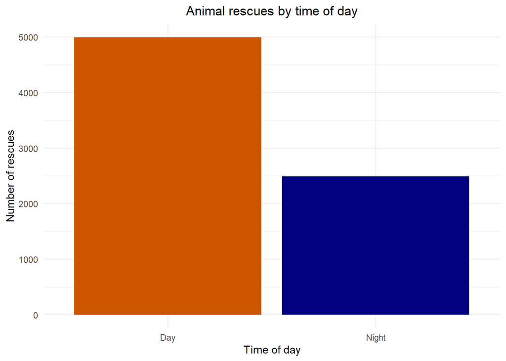

```r
ggplot(animal_rescues_interest,
  aes(day_or_night_forplots, fill = day_or_night_forplots)) +
  geom_bar() +
  labs(
    x = "Time of day",
    y = "Number of rescues",
    title = "Animal rescues by time of day"
  ) +
  scale_fill_manual(values = c("Day" = "#cc5500", "Night" = "#000080")) +
  theme_minimal() +
  theme(legend.position = "none", plot.title = element_text(hjust = 0.5))
```

## Computing domestic_wild variable and visualization

### Computing domestic_wild variable

0: domestic (traditional pets and livestock);  
1: wild (including exotic animals kept as pets)

```r
levels(animal_rescues_interest$animal_group_parent)
```

```
##  [1] "Bird"
##  [2] "Budgie"
##  [3] "Bull"
##  [4] "cat"
##  [5] "Cat"
##  [6] "Cow"
##  [7] "Deer"
##  [8] "Dog"
##  [9] "Ferret"
## [10] "Fish"
## [11] "Fox"
## [12] "Goat"
## [13] "Hamster"
## [14] "Hedgehog"
## [15] "Horse"
## [16] "Lamb"
## [17] "Lizard"
## [18] "Pigeon"
## [19] "Rabbit"
## [20] "Sheep"
## [21] "Snake"
## [22] "Squirrel"
## [23] "Tortoise"
## [24] "Unknown - Animal rescue from below ground - Farm animal"
## [25] "Unknown - Animal rescue from water - Farm animal"
## [26] "Unknown - Domestic Animal Or Pet"
## [27] "Unknown - Heavy Livestock Animal"
## [28] "Unknown - Wild Animal"
```

```r
animal_rescues_interest <- animal_rescues_interest %>%
  mutate(animal_group_parent = fct_recode(animal_group_parent,
                                          "Cat" = "cat",
                                          "Sheep" = "Lamb",
                                          "Bird" = "Pigeon",
                                          "Cow" = "Bull"))

levels(animal_rescues_interest$animal_group_parent)
```

```
##  [1] "Bird"
##  [2] "Budgie"
##  [3] "Cow"
##  [4] "Cat"
##  [5] "Deer"
##  [6] "Dog"
##  [7] "Ferret"
##  [8] "Fish"
##  [9] "Fox"
## [10] "Goat"
## [11] "Hamster"
## [12] "Hedgehog"
## [13] "Horse"
## [14] "Sheep"
## [15] "Lizard"
## [16] "Rabbit"
## [17] "Snake"
## [18] "Squirrel"
## [19] "Tortoise"
## [20] "Unknown - Animal rescue from below ground - Farm animal"
## [21] "Unknown - Animal rescue from water - Farm animal"
## [22] "Unknown - Domestic Animal Or Pet"
## [23] "Unknown - Heavy Livestock Animal"
## [24] "Unknown - Wild Animal"
```

```r
# Domestic: "Cow", "Hamster", "Horse", "Unknown - Animal rescue from water - Farm animal", "Unknown - Heavy Livestock Animal", "Cat", "Dog", "Goat", "Sheep", "Rabbit", "Unknown - Animal rescue from below ground - Farm animal", "Unknown - Domestic Animal Or Pet"

# Wild: "Bird", "Deer", "Ferret", "Hedgehog", "Fox", "Lizard", "Snake", "Tortoise", "Budgie", "Fish", "Hedgehog", "Squirrel", "Unknown - Wild Animal"

animal_rescues_interest <- animal_rescues_interest %>%
  mutate(domestic_wild = ifelse(animal_group_parent %in% c(
    "Cow", "Hamster", "Horse", "Unknown - Animal rescue from water - Farm animal",
    "Unknown - Heavy Livestock Animal", "Cat", "Dog", "Goat", "Sheep", "Rabbit",
    "Unknown - Animal rescue from below ground - Farm animal", "Unknown - Domestic Animal Or Pet"
    ), 0, 1))

animal_rescues_interest <- animal_rescues_interest %>%
  mutate(domestic_wild = as.factor(domestic_wild))
```

### Creating an extra variable for plotting

```r
animal_rescues_interest <- animal_rescues_interest %>%
  mutate(
    domestic_wild_forplots = factor(
      domestic_wild,
      levels = c(0, 1),
      labels = c("Domestic", "Wild"))
  )
```

### Checking and comparing counts of domestic and wild rescued animals via plotting

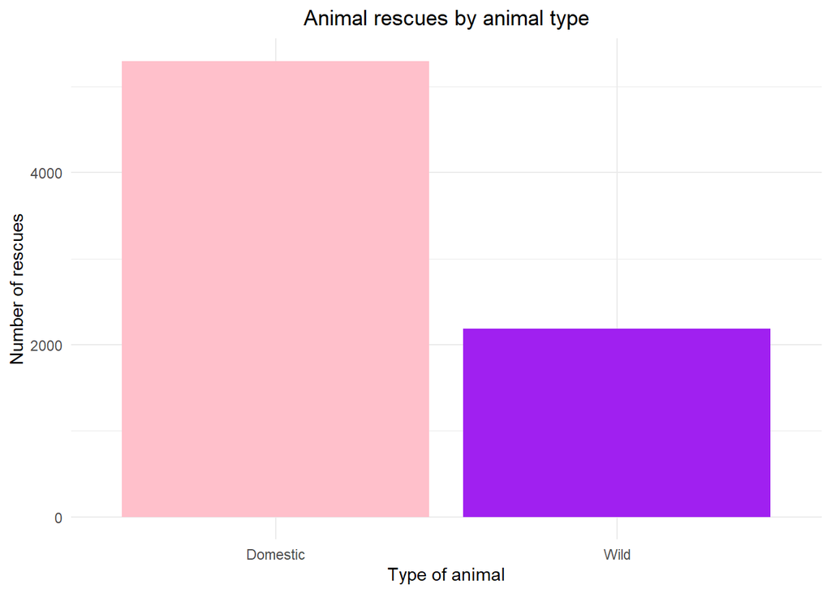

```r
ggplot(animal_rescues_interest,
  aes(domestic_wild_forplots, fill = domestic_wild_forplots)) +
  geom_bar() +
  labs(
    x = "Type of animal",
    y = "Number of rescues",
    title = "Animal rescues by animal type"
  ) +
  scale_fill_manual(values = c("Domestic" = "pink", "Wild" = "purple")) +
  theme_minimal() +
  theme(legend.position = "none", plot.title = element_text(hjust = 0.5))
```

## Computing borough_inner_outer and visualization

### Computing borough_inner_outer

0: inner;  
1: outer

```r
levels(animal_rescues_interest$borough)
```

```
##  [1] "Barking and Dagenham"   "BARKING AND DAGENHAM"   "Barnet"
##  [4] "BARNET"                 "Bexley"                 "BEXLEY"
##  [7] "Brent"                  "BRENT"                  "Brentwood"
## [10] "Bromley"                "BROMLEY"                "Broxbourne"
## [13] "Camden"                 "CAMDEN"                 "City of London"
## [16] "CITY OF LONDON"         "Croydon"                "CROYDON"
## [19] "Ealing"                 "EALING"                 "Enfield"
## [22] "ENFIELD"                "Epping Forest"          "Greenwich"
## [25] "GREENWICH"              "Hackney"                "HACKNEY"
## [28] "Hammersmith and Fulham" "HAMMERSMITH AND FULHAM" "Haringey"
## [31] "HARINGEY"               "Harrow"                 "HARROW"
## [34] "Havering"               "HAVERING"               "Hillingdon"
## [37] "HILLINGDON"             "Hounslow"               "HOUNSLOW"
## [40] "Islington"              "ISLINGTON"              "Kensington and Chelsea"
## [43] "KENSINGTON AND CHELSEA" "Kingston upon Thames"   "KINGSTON UPON THAMES"
## [46] "Lambeth"                "LAMBETH"                "Lewisham"
## [49] "LEWISHAM"               "Merton"                 "MERTON"
## [52] "Newham"                 "NEWHAM"                 "Redbridge"
## [55] "REDBRIDGE"              "Richmond upon Thames"   "RICHMOND UPON THAMES"
## [58] "Southwark"              "SOUTHWARK"              "Sutton"
## [61] "SUTTON"                 "Tandridge"              "Tower Hamlets"
## [64] "TOWER HAMLETS"          "Waltham Forest"         "WALTHAM FOREST"
## [67] "Wandsworth"             "WANDSWORTH"             "Westminster"
## [70] "WESTMINSTER"
```

```r
animal_rescues_interest <- animal_rescues_interest %>%
  mutate(borough = str_to_title(as.character(borough))) %>%
  mutate(borough = factor(borough))

levels(animal_rescues_interest$borough)
```

```
##  [1] "Barking And Dagenham"   "Barnet"                 "Bexley"
##  [4] "Brent"                  "Brentwood"              "Bromley"
##  [7] "Broxbourne"             "Camden"                 "City Of London"
## [10] "Croydon"                "Ealing"                 "Enfield"
## [13] "Epping Forest"          "Greenwich"              "Hackney"
## [16] "Hammersmith And Fulham" "Haringey"               "Harrow"
## [19] "Havering"               "Hillingdon"             "Hounslow"
## [22] "Islington"              "Kensington And Chelsea" "Kingston Upon Thames"
## [25] "Lambeth"                "Lewisham"               "Merton"
## [28] "Newham"                 "Redbridge"              "Richmond Upon Thames"
## [31] "Southwark"              "Sutton"                 "Tandridge"
## [34] "Tower Hamlets"          "Waltham Forest"         "Wandsworth"
## [37] "Westminster"
```

```r
valid_boroughs <- c(
  "Barking and Dagenham", "Barnet", "Bexley", "Brent", "Bromley", "Camden", "Croydon", "Ealing",
  "Enfield", "Greenwich", "Hackney", "Hammersmith And Fulham", "Haringey", "Harrow", "Havering",
  "Hillingdon", "Hounslow", "Islington", "Kensington And Chelsea", "Kingston upon Thames",
  "Lambeth", "Lewisham", "Merton", "Newham", "Redbridge", "Richmond Upon Thames", "Southwark",
  "Sutton", "Tower Hamlets", "Waltham Forest", "Wandsworth", "Westminster"
)

animal_rescues_interest <- animal_rescues_interest %>%
  filter(borough %in% valid_boroughs)
animal_rescues_interest$borough <- droplevels(animal_rescues_interest$borough)

levels(animal_rescues_interest$borough)
```

```
##  [1] "Barnet"                 "Bexley"                 "Brent"
##  [4] "Bromley"                "Camden"                 "Croydon"
##  [7] "Ealing"                 "Enfield"                "Greenwich"
## [10] "Hackney"                "Hammersmith And Fulham" "Haringey"
## [13] "Harrow"                 "Havering"               "Hillingdon"
## [16] "Hounslow"               "Islington"              "Kensington And Chelsea"
## [19] "Lambeth"                "Lewisham"               "Merton"
## [22] "Newham"                 "Redbridge"              "Richmond Upon Thames"
## [25] "Southwark"              "Sutton"                 "Tower Hamlets"
## [28] "Waltham Forest"         "Wandsworth"             "Westminster"
```

```r
nlevels(animal_rescues_interest$borough)
```

```
## [1] 30
```

```r
# inner boroughs: "Camden", "Greenwich", "Hackney", "Hammersmith And Fulham", "Islington", "Kensington And Chelsea", "Lambeth", "Lewisham", "Southwark", "Tower Hamlets", "Wandsworth", "Westminster"

animal_rescues_interest <- animal_rescues_interest %>%
  mutate(borough_inner_outer = ifelse(borough %in% c(
    "Camden", "Greenwich", "Hackney", "Hammersmith And Fulham", "Islington", "Kensington And Chelsea", "Lambeth",
    "Lewisham", "Southwark", "Tower Hamlets", "Wandsworth", "Westminster"
    ), 0, 1))

animal_rescues_interest <- animal_rescues_interest %>%
  mutate(borough_inner_outer = as.factor(borough_inner_outer))
```

### Creating an extra variable for plotting

```r
animal_rescues_interest <- animal_rescues_interest %>%
  mutate(
    borough_inner_outer_forplots = factor(
      borough_inner_outer,
      levels = c(0, 1),
      labels = c("Inner", "Outer"))
  )
```

### Checking and comparing counts of animal rescues in inner and outer boroughs of London via plotting

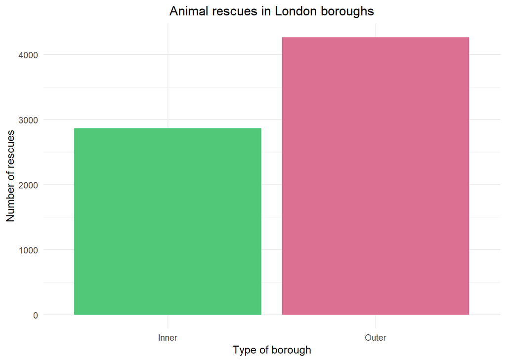

```r
ggplot(animal_rescues_interest,
  aes(borough_inner_outer_forplots, fill = borough_inner_outer_forplots)) +
  geom_bar() +
  labs(
    x = "Type of borough",
    y = "Number of rescues",
    title = "Animal rescues in London boroughs"
  ) +
  scale_fill_manual(values = c("Inner" = "#50c878", "Outer" = "#db7093")) +
  theme_minimal() +
  theme(legend.position = "none", plot.title = element_text(hjust = 0.5))
```

## Exploring distribution of remaining variables of interest

### Exploring distribution of pump_count

```r
mean(animal_rescues_interest$pump_count)
```

```
## [1] 1.020749
```

```r
sd(animal_rescues_interest$pump_count)
```

```
## [1] 0.1548112
```

```r
min(animal_rescues_interest$pump_count)
```

```
## [1] 1
```

```r
max(animal_rescues_interest$pump_count)
```

```
## [1] 4
```

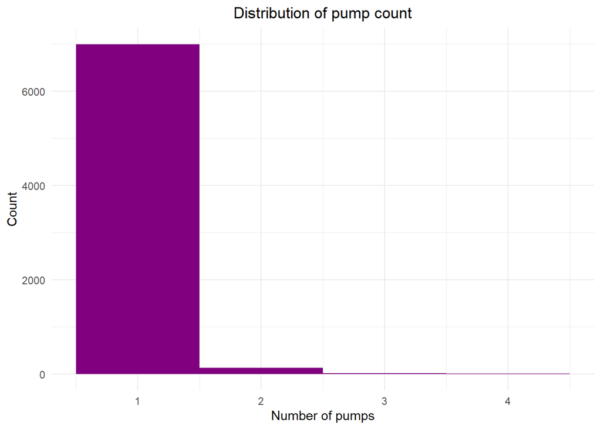

```r
ggplot(animal_rescues_interest, aes(pump_count)) +
  geom_histogram(binwidth = 1, fill = "#800080") +
  labs(
    x = "Number of pumps",
    y = "Count",
    title = "Distribution of pump count"
  ) +
  theme_minimal() +
  theme(plot.title = element_text(hjust = 0.5))
```

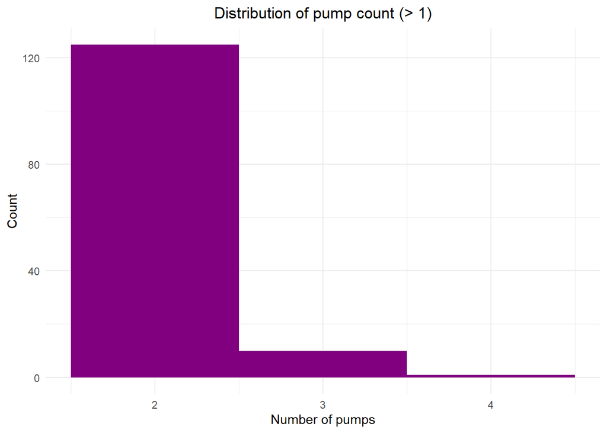

```r
# Due to pump_count = 1 overwhelming the plot, here is another plot with pump_count > 1

ggplot(animal_rescues_interest %>% filter(pump_count > 1), aes(pump_count)) +
  geom_histogram(binwidth = 1, fill = "#800080") +
  labs(
    x = "Number of pumps",
    y = "Count",
    title = "Distribution of pump count (> 1)"
  ) +
  theme_minimal() +
  theme(plot.title = element_text(hjust = 0.5))
```

### Exploring distribution of pump_hours_total

```r
mean(animal_rescues_interest$pump_hours_total)
```

```
## [1] 1.183794
```

```r
sd(animal_rescues_interest$pump_hours_total)
```

```
## [1] 0.6422722
```

```r
min(animal_rescues_interest$pump_hours_total)
```

```
## [1] 0
```

```r
max(animal_rescues_interest$pump_hours_total)
```

```
## [1] 12
```

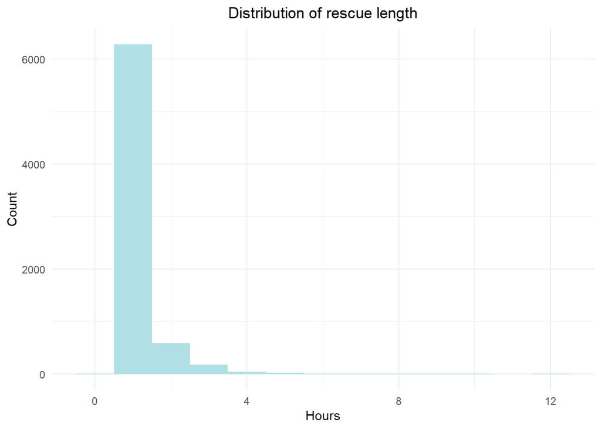

```r
ggplot(animal_rescues_interest, aes(pump_hours_total)) +
  geom_histogram(binwidth = 1, fill = "#b0e0e6") +
  labs(
    x = "Hours",
    y = "Count",
    title = "Distribution of rescue length"
  ) +
  theme_minimal() +
  theme(plot.title = element_text(hjust = 0.5))
```

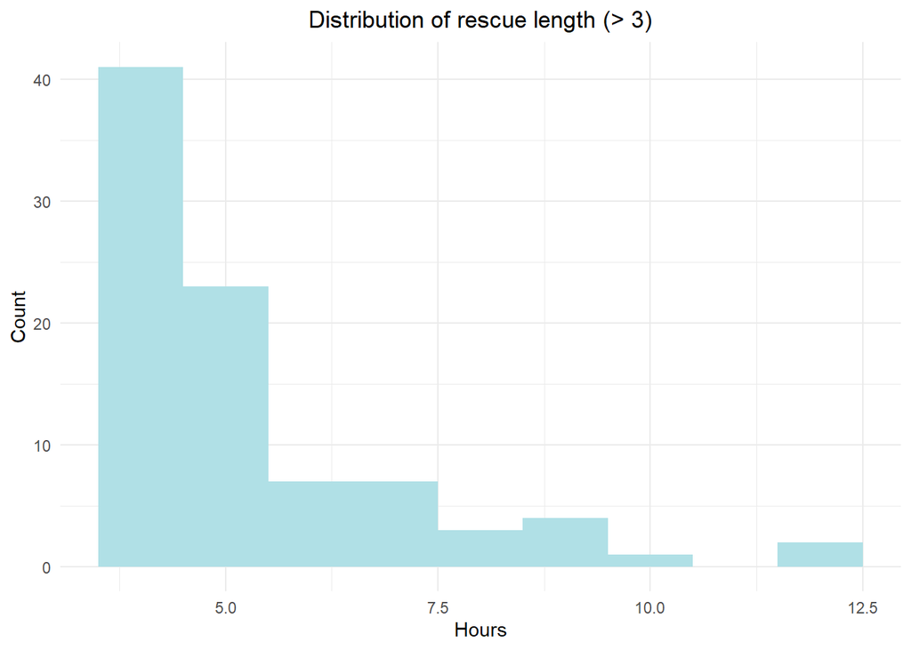

```r
# Due to low values overwhelming the plot, here is another plot with pump_hours_total > 3

ggplot(animal_rescues_interest %>% filter(pump_hours_total > 3), aes(pump_hours_total)) +
  geom_histogram(binwidth = 1, fill = "#b0e0e6") +
  labs(
    x = "Hours",
    y = "Count",
    title = "Distribution of rescue length (> 3)"
  ) +
  theme_minimal() +
  theme(plot.title = element_text(hjust = 0.5))
```

### Exploring distribution of incident_notional_cost

```r
mean(animal_rescues_interest$incident_notional_cost)
```

```
## [1] 356.5498
```

```r
sd(animal_rescues_interest$incident_notional_cost)
```

```
## [1] 196.5374
```

```r
min(animal_rescues_interest$incident_notional_cost)
```

```
## [1] 0
```

```r
max(animal_rescues_interest$incident_notional_cost)
```

```
## [1] 3912
```

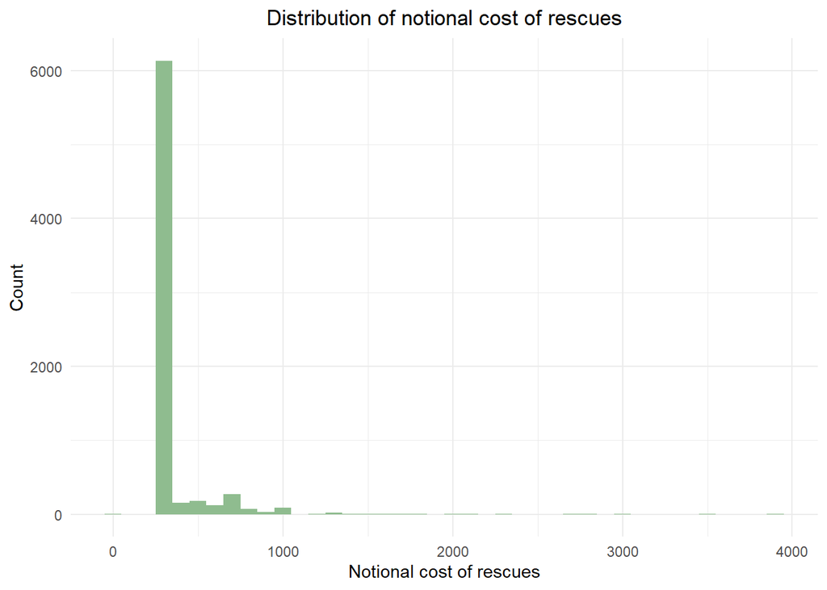

```r
ggplot(animal_rescues_interest, aes(incident_notional_cost)) +
  geom_histogram(binwidth = 100, fill = "#8fbc8f") +
  labs(
    x = "Notional cost of rescues",
    y = "Count",
    title = "Distribution of notional cost of rescues"
  ) +
  theme_minimal() +
  theme(plot.title = element_text(hjust = 0.5))
```

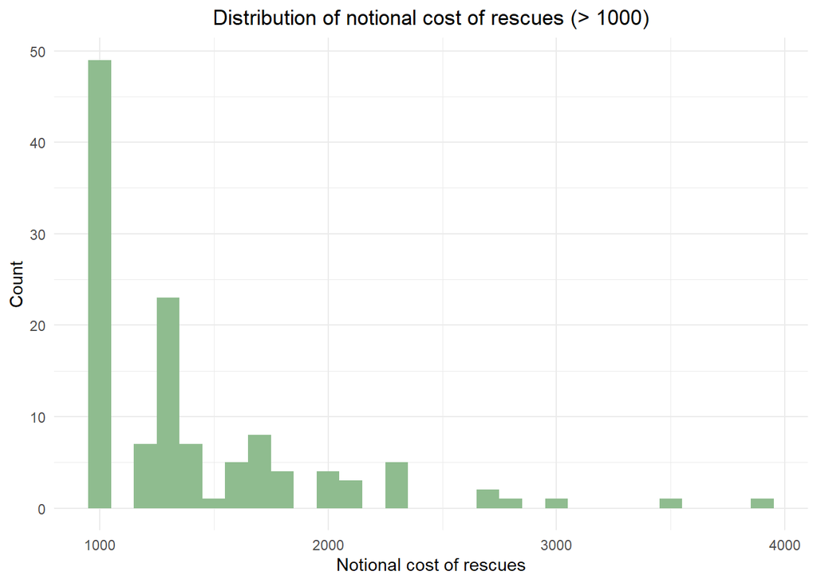

```r
# Due to low values overwhelming the plot, here is another plot with incident_notional_cost > 1000

ggplot(animal_rescues_interest %>% filter(incident_notional_cost > 1000), aes(incident_notional_cost)) +
  geom_histogram(binwidth = 100, fill = "#8fbc8f") +
  labs(
    x = "Notional cost of rescues",
    y = "Count",
    title = "Distribution of notional cost of rescues (> 1000)"
  ) +
  theme_minimal() +
  theme(plot.title = element_text(hjust = 0.5))
```

Since the cost of the rescue is the main focus of my analysis (I want to know what causes the extreme values), I will not filter out the extreme values.

# 🐾 Confirming the rise in rescues by plotting 🐾

According to the dataset description, there was an increase in rescues in 2020, especially when it comes to wild animals. In this section, I will confirm this trend via plotting.

## Grouping by year and calculating the count of rescues per year

```r
rescues_per_year <- animal_rescues_interest %>%
  group_by(cal_year, domestic_wild_forplots) %>%
  summarise(rescue_count = n())
```

## Plotting (both for domestic and wild animals)

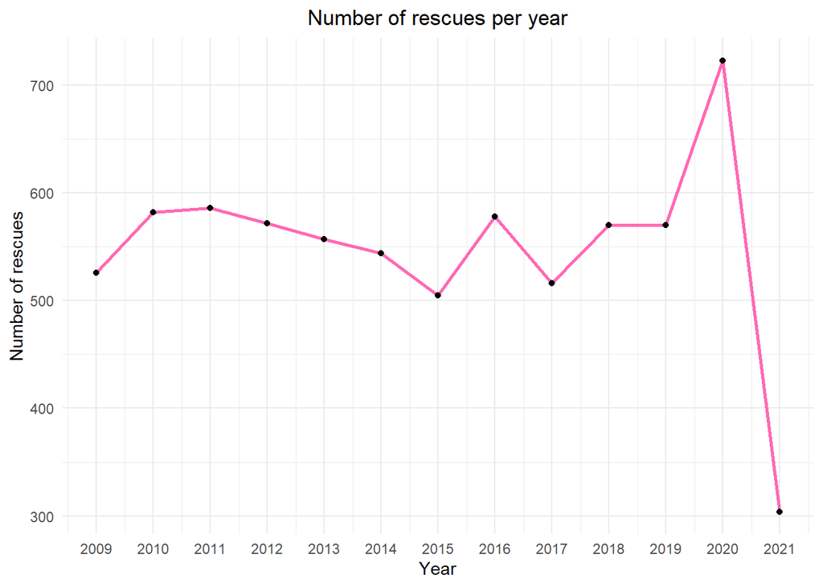

```r
# Grouping by year and summarizing rescues
rescues_per_year_aggregated <- rescues_per_year %>%
  group_by(cal_year) %>%
  summarise(rescue_count = sum(rescue_count))

# Plotting
ggplot(rescues_per_year_aggregated, aes(cal_year, rescue_count, group = 1)) +
  geom_line(color = "#ff69b4", linewidth = 1) +
  geom_point() +
  scale_x_continuous(breaks = 2009:2021) +
  labs(
    x = "Year",
    y = "Number of rescues",
    title = "Number of rescues per year"
  ) +
  theme_minimal() +
  theme(plot.title = element_text(hjust = 0.5))
```

## Plotting (separate lines for domestic and wild animals)

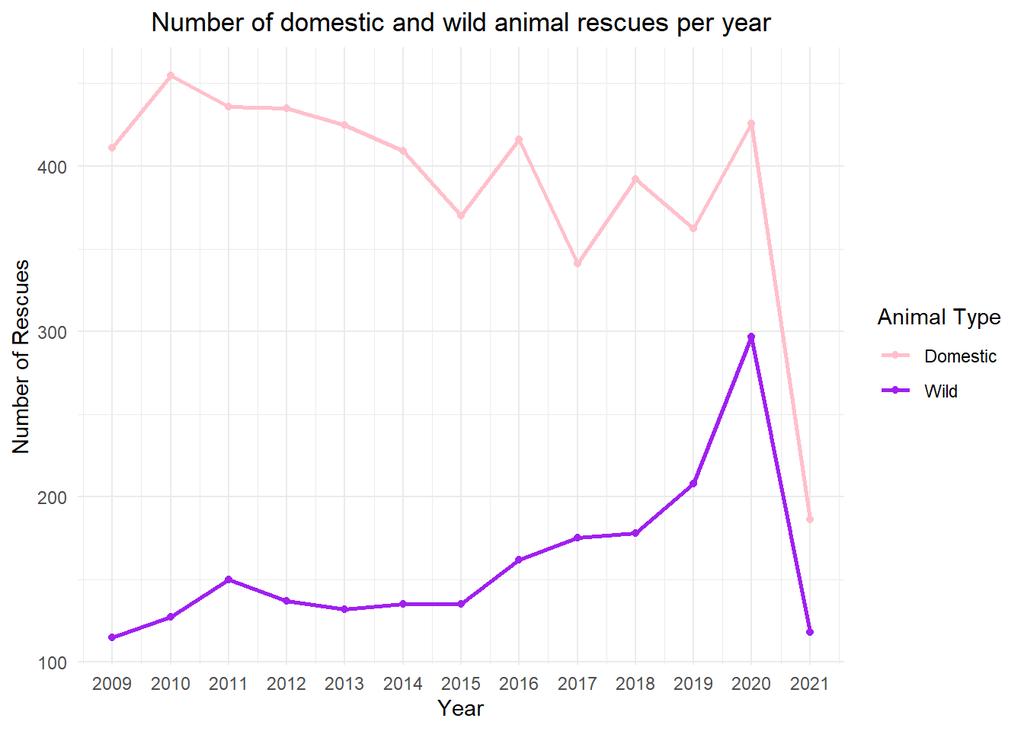

```r
ggplot(rescues_per_year,
  aes(cal_year, rescue_count, color = domestic_wild_forplots, group = domestic_wild_forplots)) +
  geom_line(linewidth = 1) +
  geom_point() +
  scale_x_continuous(breaks = 2009:2021) +
  scale_color_manual(values = c("Domestic" = "pink", "Wild" = "purple")) +
  labs(
    x = "Year",
    y = "Number of Rescues",
    title = "Number of domestic and wild animal rescues per year",
    color = "Animal Type"
  ) +
  theme_minimal() +
  theme(plot.title = element_text(hjust = 0.5))
```

### Calculating increase in domestic and wild animal rescues in 2020

```r
rescues_change_comparison <- rescues_per_year %>%
  filter(cal_year %in% c(2019, 2020)) %>%
  group_by(domestic_wild_forplots) %>%
  pivot_wider(names_from = cal_year, values_from = rescue_count) %>%
  mutate(increase = `2020` - `2019`)

print(rescues_change_comparison)
```

```
## # A tibble: 2 × 4
## # Groups:   domestic_wild_forplots [2]
##   domestic_wild_forplots `2019` `2020` increase
##   <fct>                   <int>  <int>    <int>
## 1 Domestic                  362    426       64
## 2 Wild                      208    297       89
```

Conclusion: Indeed, in 2020 there was an increase in animal rescues, especially in wild animal rescues.

# 🐾 Relationships between variables of interest 🐾

## Checking correlations

```r
correlations <- animal_rescues_interest %>%
  select(incident_notional_cost, cal_year, pump_count, pump_hours_total, day_or_night, domestic_wild, borough_inner_outer) %>%
  mutate(
    day_or_night = as.numeric(day_or_night),
    domestic_wild = as.numeric(domestic_wild),
    borough_inner_outer = as.numeric(borough_inner_outer)) %>%
  correlation() %>%
  print()
```

```
## # Correlation Matrix (pearson-method)
##
## Parameter1             |          Parameter2 |         r |         95% CI | t(7131) |         p
## -----------------------------------------------------------------------------------------------
## incident_notional_cost |            cal_year |      0.19 | [ 0.17,  0.21] |   16.16 | < .001***
## incident_notional_cost |          pump_count |      0.62 | [ 0.60,  0.63] |   66.56 | < .001***
## incident_notional_cost |    pump_hours_total |      0.97 | [ 0.97,  0.97] |  354.88 | < .001***
## incident_notional_cost |        day_or_night |     -0.05 | [-0.07, -0.02] |   -4.06 | < .001***
## incident_notional_cost |       domestic_wild | -7.43e-03 | [-0.03,  0.02] |   -0.63 | > .999
## incident_notional_cost | borough_inner_outer |      0.05 | [ 0.02,  0.07] |    3.83 | 0.002**
## cal_year               |          pump_count |     -0.03 | [-0.06, -0.01] |   -2.94 | 0.026*
## cal_year               |    pump_hours_total |     -0.01 | [-0.03,  0.01] |   -0.93 | > .999
## cal_year               |        day_or_night |      0.03 | [ 0.01,  0.05] |    2.46 | 0.084
## cal_year               |       domestic_wild |      0.13 | [ 0.11,  0.15] |   11.10 | < .001***
## cal_year               | borough_inner_outer |  7.68e-03 | [-0.02,  0.03] |    0.65 | > .999
## pump_count             |    pump_hours_total |      0.65 | [ 0.64,  0.67] |   72.74 | < .001***
## pump_count             |        day_or_night |     -0.04 | [-0.06, -0.02] |   -3.32 | 0.008**
## pump_count             |       domestic_wild | -3.85e-03 | [-0.03,  0.02] |   -0.33 | > .999
## pump_count             | borough_inner_outer |      0.02 | [ 0.00,  0.04] |    1.78 | 0.373
## pump_hours_total       |        day_or_night |     -0.05 | [-0.08, -0.03] |   -4.55 | < .001***
## pump_hours_total       |       domestic_wild |     -0.03 | [-0.06, -0.01] |   -2.94 | 0.026*
## pump_hours_total       | borough_inner_outer |      0.05 | [ 0.02,  0.07] |    3.97 | < .001***
## day_or_night           |       domestic_wild |     -0.05 | [-0.08, -0.03] |   -4.63 | < .001***
## day_or_night           | borough_inner_outer |     -0.04 | [-0.07, -0.02] |   -3.63 | 0.003**
## domestic_wild          | borough_inner_outer |      0.04 | [ 0.02,  0.06] |    3.39 | 0.007**
##
## p-value adjustment method: Holm (1979)
## Observations: 7133
```

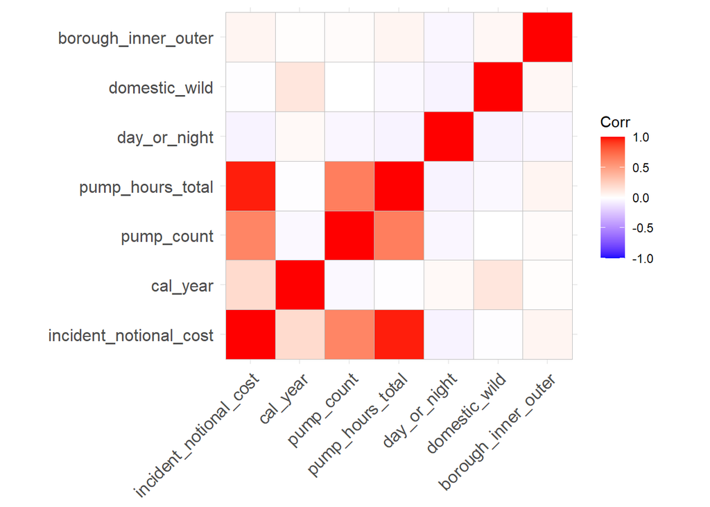

```r
ggcorrplot(correlations)
```

The main focus is incident_notional_cost, the price of rescues, so I will interpret the correlations concerning incident_notional_cost:

1. Weak positive correlation with cal_year: rescues became more expensive over time
2. Strong positive correlation with pump_count: if more pumps are necessary, the rescue becomes more expensive
3. Strong positive correlation with pump_hours_total: longer rescues are more expensive
4. Weak negative correlation with day_or_night: night rescues are a bit cheaper (maybe due to less traffic?)
5. No significant correlation with domestic_wild (but domestic animals are little bit more expensive)
6. Weak positive correlation with borough_inner_outer: rescues in outer boroughs are slightly more expensive

## Checking for differences

### Price differences according to animal type

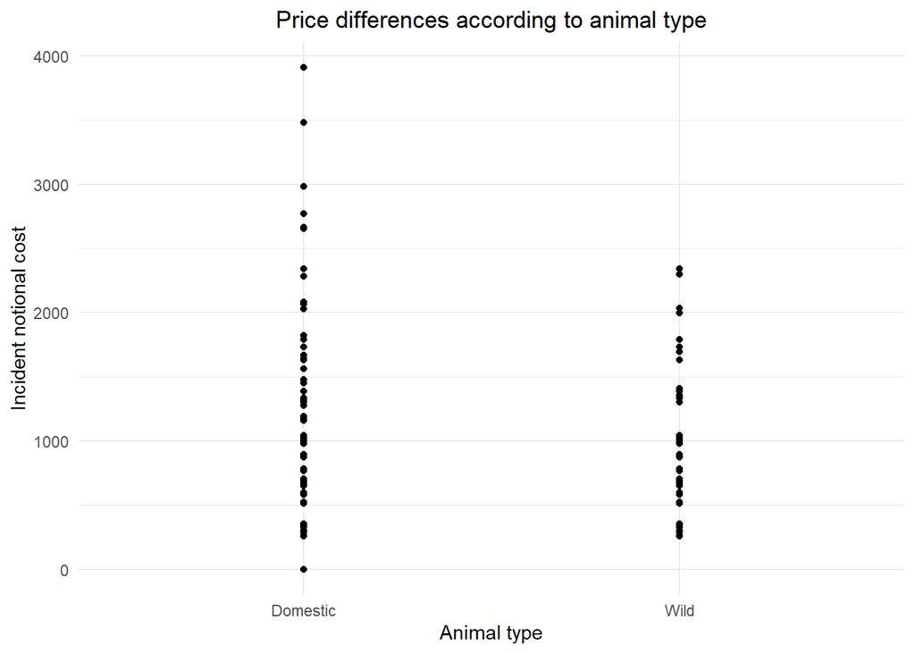

```r
ggplot(animal_rescues_interest, aes(domestic_wild_forplots, incident_notional_cost)) +
  geom_point() +
  labs(
    x = "Animal type",
    y = "Incident notional cost",
    title = "Price differences according to animal type",
  ) +
  theme_minimal() +
  theme(plot.title = element_text(hjust = 0.5))
```

### Price differences according to day and night calls

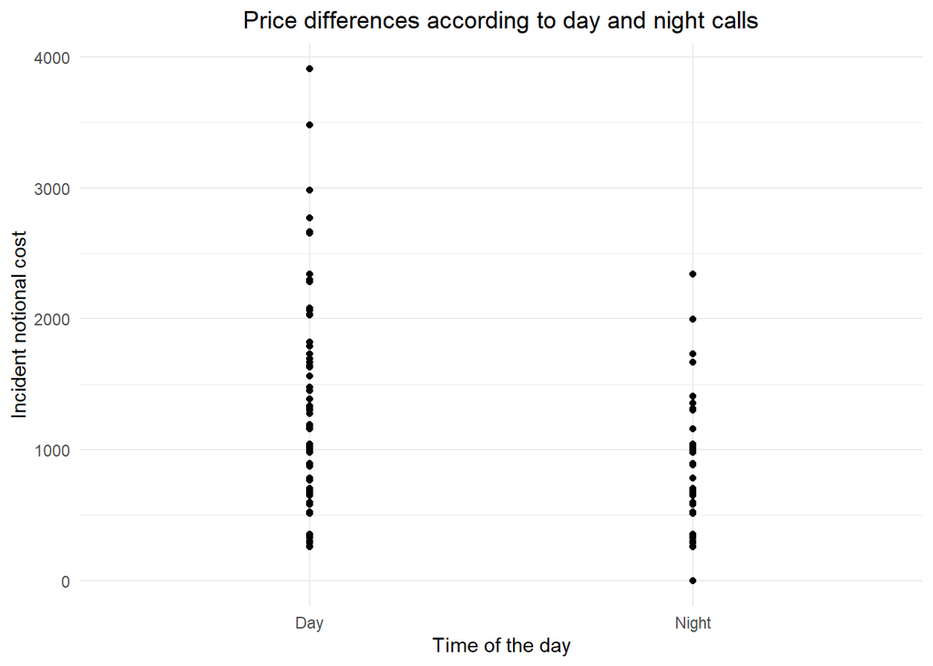

```r
ggplot(animal_rescues_interest, aes(day_or_night_forplots, incident_notional_cost)) +
  geom_point() +
  labs(
    x = "Time of the day",
    y = "Incident notional cost",
    title = "Price differences according to day and night calls",
  ) +
  theme_minimal() +
  theme(plot.title = element_text(hjust = 0.5))
```

### Price differences according to boroughs

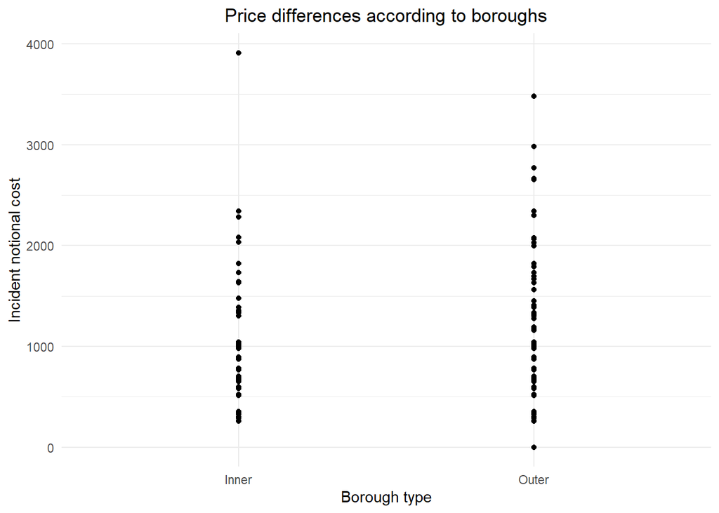

```r
ggplot(animal_rescues_interest, aes(borough_inner_outer_forplots, incident_notional_cost)) +
  geom_point() +
  labs(
    x = "Borough type",
    y = "Incident notional cost",
    title = "Price differences according to boroughs",
  ) +
  theme_minimal() +
  theme(plot.title = element_text(hjust = 0.5))
```

## Checking for linear relationships

incident_notional_cost ~ other variables via plotting

### Relationship with cal_year

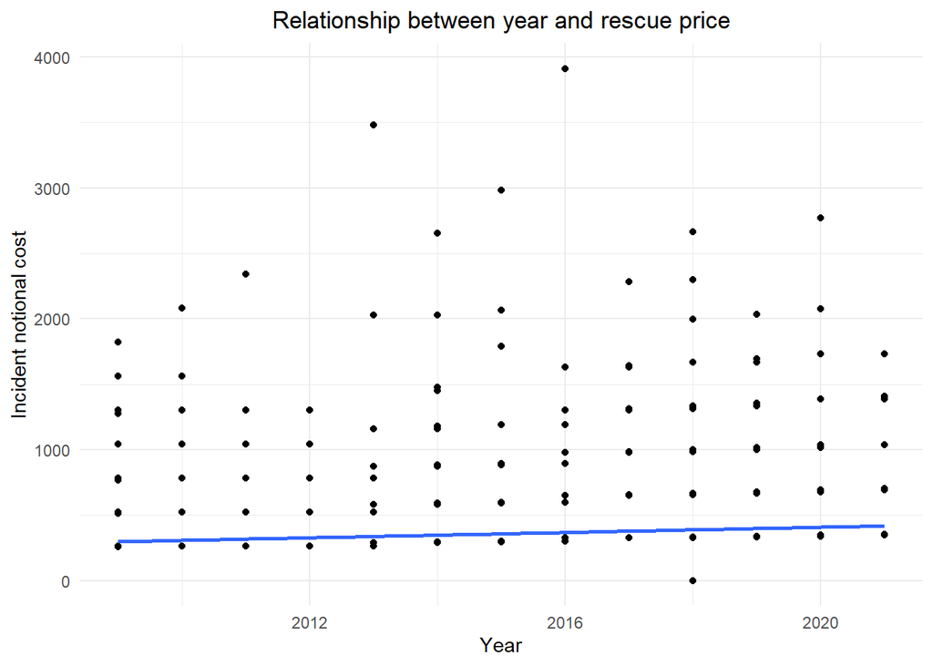

```r
ggplot(animal_rescues_interest, aes(cal_year, incident_notional_cost)) +
  geom_point() +
  geom_smooth(method = "lm", se = FALSE) +
  labs(
    x = "Year",
    y = "Incident notional cost",
    title = "Relationship between year and rescue price",
  ) +
  theme_minimal() +
  theme(plot.title = element_text(hjust = 0.5))
```

### Relationship with pump_count

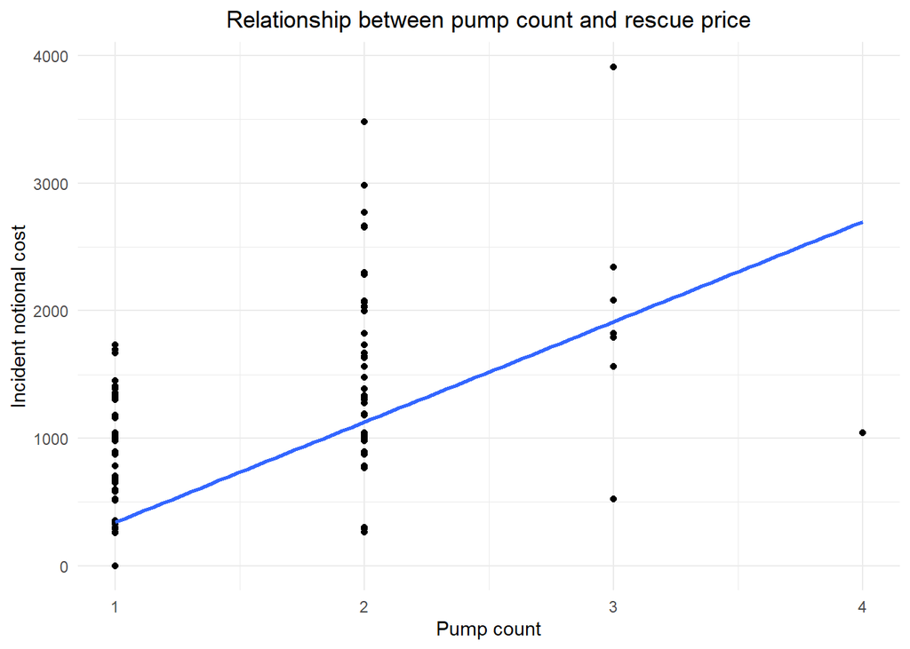

```r
ggplot(animal_rescues_interest, aes(pump_count, incident_notional_cost)) +
  geom_point() +
  geom_smooth(method = "lm", se = FALSE) +
  labs(
    x = "Pump count",
    y = "Incident notional cost",
    title = "Relationship between pump count and rescue price",
  ) +
  theme_minimal() +
  theme(plot.title = element_text(hjust = 0.5))
```

### Relationship with pump_hours_total

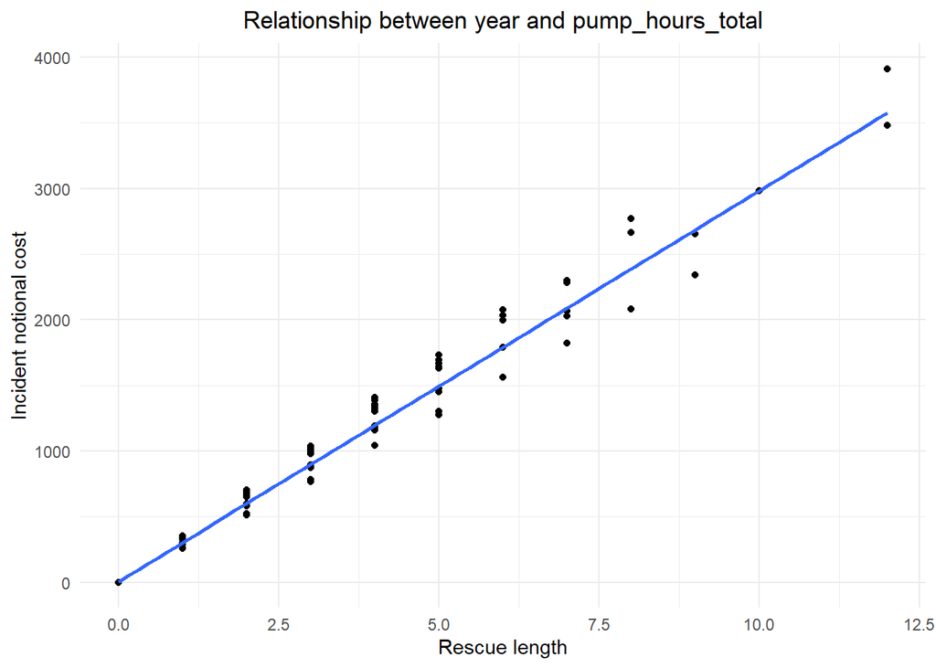

```r
ggplot(animal_rescues_interest, aes(pump_hours_total, incident_notional_cost)) +
  geom_point() +
  geom_smooth(method = "lm", se = FALSE) +
  labs(
    x = "Rescue length",
    y = "Incident notional cost",
    title = "Relationship between year and pump_hours_total",
  ) +
  theme_minimal() +
  theme(plot.title = element_text(hjust = 0.5))
```

# 🐾 Building null model 🐾

In this section I am going to investigating whether non-domestic animals’ rescue costs more money than domestic animals’ rescue by fitting a linear regression model.

Outcome variable: incident_notional_cost;  
Predictor: domestic_wild

## Fitting null model

```r
nullmodel <- lm(incident_notional_cost ~ domestic_wild, data = animal_rescues_interest)
```

## Extracting statistics and coefficients of null model, computing standardized coefficients

```r
# Model statistics
glance(nullmodel)
```

```
## # A tibble: 1 × 12
##   r.squared adj.r.squared sigma statistic p.value    df  logLik    AIC    BIC
##       <dbl>         <dbl> <dbl>     <dbl>   <dbl> <dbl>   <dbl>  <dbl>  <dbl>
## 1 0.0000551    -0.0000851  197.     0.393   0.531     1 -47789. 95584. 95604.
## # ℹ 3 more variables: deviance <dbl>, df.residual <int>, nobs <int>
```

```r
# Extracting coefficients of null model
summary(nullmodel)
```

```
##
## Call:
## lm(formula = incident_notional_cost ~ domestic_wild, data = animal_rescues_interest)
##
## Residuals:
##    Min     1Q Median     3Q    Max
## -357.5  -94.3  -31.5  -15.3 3554.5
##
## Coefficients:
##                Estimate Std. Error t value Pr(>|t|)
## (Intercept)     357.483      2.762 129.431   <2e-16 ***
## domestic_wild1   -3.216      5.128  -0.627    0.531
## ---
## Signif. codes:  0 '***' 0.001 '**' 0.01 '*' 0.05 '.' 0.1 ' ' 1
##
## Residual standard error: 196.5 on 7131 degrees of freedom
## Multiple R-squared:  5.514e-05,  Adjusted R-squared:  -8.509e-05
## F-statistic: 0.3932 on 1 and 7131 DF,  p-value: 0.5306
```

```r
tidy(nullmodel, conf.int = TRUE)
```

```
## # A tibble: 2 × 7
##   term           estimate std.error statistic p.value conf.low conf.high
##   <chr>             <dbl>     <dbl>     <dbl>   <dbl>    <dbl>     <dbl>
## 1 (Intercept)      357.        2.76   129.      0        352.     363.
## 2 domestic_wild1    -3.22      5.13    -0.627   0.531    -13.3      6.84
```

```r
# Computing standardized beta coefficients
nullmodel_standardized <- lm.beta(nullmodel)
coef(nullmodel_standardized)
```

```
##    (Intercept) domestic_wild1
##             NA   -0.007425621
```

## Extracting specific model test statistics of null model and putting them into a table

```r
adjusted_r2_nullmodel <- glance(nullmodel) %>% pull(adj.r.squared)
f_statistic_nullmodel <- glance(nullmodel) %>% pull(statistic)
p_value_nullmodel <- glance(nullmodel) %>% pull(p.value)
df_nullmodel <- glance(nullmodel) %>% pull(df)
AIC_nullmodel <- glance(nullmodel) %>% pull(AIC)

model_stats_nullmodel <- tibble(
  Statistic = c("Adjusted R-squared", "F-statistic", "p-value", "Degrees of Freedom", "AIC"),
  Value = c(adjusted_r2_nullmodel, f_statistic_nullmodel, p_value_nullmodel, df_nullmodel, AIC_nullmodel))

print(model_stats_nullmodel)
```

```
## # A tibble: 5 × 2
##   Statistic                  Value
##   <chr>                      <dbl>
## 1 Adjusted R-squared    -0.0000851
## 2 F-statistic            0.393
## 3 p-value                0.531
## 4 Degrees of Freedom     1
## 5 AIC                95584.
```

## Extracting coefficients of null model and putting them into a table

```r
standardized_coefficients_nullmodel <- (coef(nullmodel_standardized))[-1]

coeff_extracted_nullmodel <- tidy(nullmodel, conf.int = TRUE) %>%
  select(term, estimate, conf.low, conf.high, p.value) %>%
  mutate(standardized = c(NA, standardized_coefficients_nullmodel))

print(coeff_extracted_nullmodel)
```

```
## # A tibble: 2 × 6
##   term           estimate conf.low conf.high p.value standardized
##   <chr>             <dbl>    <dbl>     <dbl>   <dbl>        <dbl>
## 1 (Intercept)      357.      352.     363.     0         NA
## 2 domestic_wild1    -3.22    -13.3      6.84   0.531     -0.00743
```

## Checking the model

### Cook’s distance for null model and checking for influential outliers (Cook’s distance > 1)

```r
cooks_distance_nullmodel <- cooks.distance(nullmodel)
influential_outliers_nullmodel <- which(cooks_distance_nullmodel > 1)
influential_outliers_nullmodel
```

```
## named integer(0)
```

```r
# There are no influential outliers according to the test.
```

### Q-Q plot for residual normality check

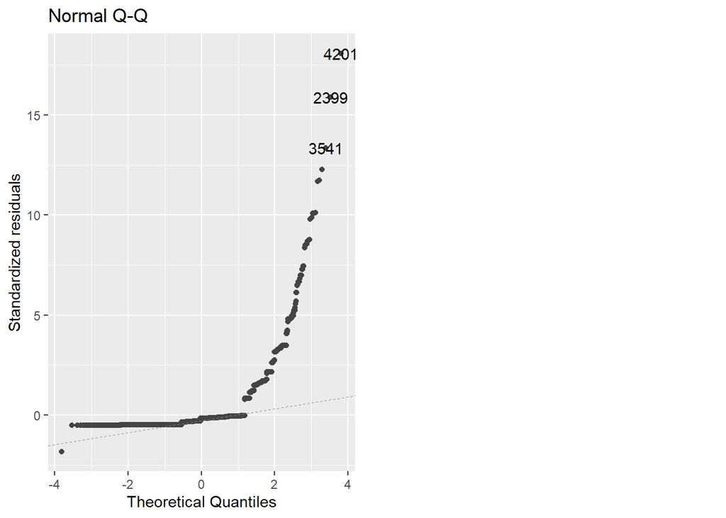

```r
autoplot(nullmodel, which = 2)
```

```r
# The plot shows that residuals are not normally distributed.

# Computing leverage values and checking leverage for specific observations that deviate from the Q-Q plot line
leverage_values <- hatvalues(nullmodel)
leverage_values[c(3541, 2399, 4201)]
```

```
##         3541         2399         4201
## 0.0001974724 0.0001974724 0.0001974724
```

```r
## Viewing observations that might be influential
animal_rescues_interest[3541, ]
```

```
## # A tibble: 1 × 13
##   date_time_of_call   cal_year pump_count pump_hours_total
##   <dttm>                 <dbl>      <dbl>            <dbl>
## 1 2015-05-22 11:34:00     2015          2               10
## # ℹ 9 more variables: incident_notional_cost <dbl>, animal_group_parent <fct>,
## #   borough <fct>, day_or_night <dbl>, day_or_night_forplots <fct>,
## #   domestic_wild <fct>, domestic_wild_forplots <fct>,
## #   borough_inner_outer <fct>, borough_inner_outer_forplots <fct>
```

```r
animal_rescues_interest[2399, ]
```

```
## # A tibble: 1 × 13
##   date_time_of_call   cal_year pump_count pump_hours_total
##   <dttm>                 <dbl>      <dbl>            <dbl>
## 1 2013-04-19 07:01:00     2013          2               12
## # ℹ 9 more variables: incident_notional_cost <dbl>, animal_group_parent <fct>,
## #   borough <fct>, day_or_night <dbl>, day_or_night_forplots <fct>,
## #   domestic_wild <fct>, domestic_wild_forplots <fct>,
## #   borough_inner_outer <fct>, borough_inner_outer_forplots <fct>
```

```r
animal_rescues_interest[4201, ]
```

```
## # A tibble: 1 × 13
##   date_time_of_call   cal_year pump_count pump_hours_total
##   <dttm>                 <dbl>      <dbl>            <dbl>
## 1 2016-07-28 13:49:00     2016          3               12
## # ℹ 9 more variables: incident_notional_cost <dbl>, animal_group_parent <fct>,
## #   borough <fct>, day_or_night <dbl>, day_or_night_forplots <fct>,
## #   domestic_wild <fct>, domestic_wild_forplots <fct>,
## #   borough_inner_outer <fct>, borough_inner_outer_forplots <fct>
```

```r
# Horses and a cat with high rescue costs.
```

### Independence of residuals (Durbin-Watson test)

```r
dwtest(nullmodel)
```

```
##
##  Durbin-Watson test
##
## data:  nullmodel
## DW = 1.9365, p-value = 0.003676
## alternative hypothesis: true autocorrelation is greater than 0
```

```r
# Positive autocorrelation between residuals.
```

### Residuals vs. fitted plot to check linearity and homoskedasticity

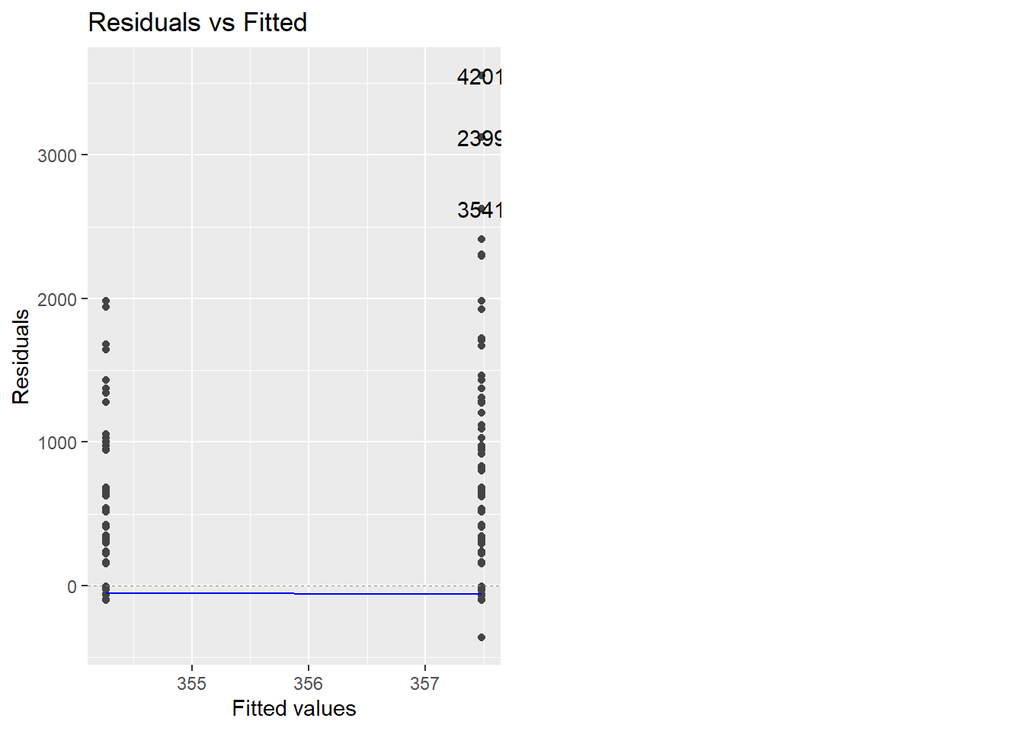

```r
autoplot(nullmodel, which = 1)
```

```r
# Linearity is not applicable because the only predictor is a factor.
# There are outlier residuals.
# Homoskedasticity is not violated.
```

Due to assumption violations, I will try log-transforming the outcome variable (incident_notional_cost), and check whether the model improves.

## Fitting null model with log-transformed outcome variable

```r
animal_rescues_interest <- animal_rescues_interest %>%
  mutate(log_incident_notional_cost = log(incident_notional_cost + 1))

nullmodel_log <- lm(log_incident_notional_cost ~ domestic_wild, data = animal_rescues_interest)
```

## Extracting statistics and coefficients of log-transformed null model, computing standardized coefficients

```r
# Model statistics
glance(nullmodel_log)
```

```
## # A tibble: 1 × 12
##   r.squared adj.r.squared sigma statistic p.value    df logLik   AIC   BIC
##       <dbl>         <dbl> <dbl>     <dbl>   <dbl> <dbl>  <dbl> <dbl> <dbl>
## 1  0.000106    -0.0000344 0.330     0.754   0.385     1 -2202. 4411. 4431.
## # ℹ 3 more variables: deviance <dbl>, df.residual <int>, nobs <int>
```

```r
#Coefficients
summary(nullmodel_log)
```

```
##
## Call:
## lm(formula = log_incident_notional_cost ~ domestic_wild, data = animal_rescues_interest)
##
## Residuals:
##     Min      1Q  Median      3Q     Max
## -5.8058 -0.2412 -0.0233  0.0232  2.4663
##
## Coefficients:
##                Estimate Std. Error  t value Pr(>|t|)
## (Intercept)    5.805769   0.004631 1253.684   <2e-16 ***
## domestic_wild1 0.007469   0.008599    0.869    0.385
## ---
## Signif. codes:  0 '***' 0.001 '**' 0.01 '*' 0.05 '.' 0.1 ' ' 1
##
## Residual standard error: 0.3295 on 7131 degrees of freedom
## Multiple R-squared:  0.0001058,  Adjusted R-squared:  -3.442e-05
## F-statistic: 0.7545 on 1 and 7131 DF,  p-value: 0.3851
```

```r
tidy(nullmodel_log, conf.int = TRUE)
```

```
## # A tibble: 2 × 7
##   term           estimate std.error statistic p.value conf.low conf.high
##   <chr>             <dbl>     <dbl>     <dbl>   <dbl>    <dbl>     <dbl>
## 1 (Intercept)     5.81      0.00463  1254.      0      5.80       5.81
## 2 domestic_wild1  0.00747   0.00860     0.869   0.385 -0.00939    0.0243
```

```r
# Computing standardized beta coefficients
nullmodel_log_standardized <- lm.beta(nullmodel_log)
coef(nullmodel_log_standardized)
```

```
##    (Intercept) domestic_wild1
##             NA      0.0102856
```

## Extracting specific model test statistics of log-transformed null model and putting them into a table

```r
adjusted_r2_nullmodel_log <- glance(nullmodel_log) %>% pull(adj.r.squared)
f_statistic_nullmodel_log <- glance(nullmodel_log) %>% pull(statistic)
p_value_nullmodel_log <- glance(nullmodel_log) %>% pull(p.value)
df_nullmodel_log <- glance(nullmodel_log) %>% pull(df)
AIC_nullmodel_log <- glance(nullmodel_log) %>% pull(AIC)

model_stats_nullmodel_log <- tibble(
  Statistic = c("Adjusted R-squared", "F-statistic", "p-value", "Degrees of Freedom", "AIC"),
  Value = c(adjusted_r2_nullmodel_log, f_statistic_nullmodel_log, p_value_nullmodel_log, df_nullmodel_log, AIC_nullmodel_log))

print(model_stats_nullmodel_log)
```

```
## # A tibble: 5 × 2
##   Statistic                 Value
##   <chr>                     <dbl>
## 1 Adjusted R-squared   -0.0000344
## 2 F-statistic           0.754
## 3 p-value               0.385
## 4 Degrees of Freedom    1
## 5 AIC                4411.
```

## Extracting coefficients of log-transformed null model and putting them into a table

```r
standardized_coefficients_nullmodel_log <- (coef(nullmodel_log_standardized))[-1]

coeff_extracted_nullmodel_log <- tidy(nullmodel_log, conf.int = TRUE) %>%
  select(term, estimate, conf.low, conf.high, p.value) %>%
  mutate(standardized = c(NA, standardized_coefficients_nullmodel_log))

print(coeff_extracted_nullmodel_log)
```

```
## # A tibble: 2 × 6
##   term           estimate conf.low conf.high p.value standardized
##   <chr>             <dbl>    <dbl>     <dbl>   <dbl>        <dbl>
## 1 (Intercept)     5.81     5.80       5.81     0          NA
## 2 domestic_wild1  0.00747 -0.00939    0.0243   0.385       0.0103
```